# Lab 10: Simulation Exploration

Author

Agustin Fleisher

```r
library(tidyverse)
library(broom)
library(gt)
library(scales)
```

## Random Babies Simulation

Perhaps you have seen the [Random Babies applet](https://www.rossmanchance.com/applets/2021/randombabies/RandomBabies.html)? Suppose one night at a hospital some number of babies are born. The hospital is not very organized and looses track of which baby belongs to each parent(s), so they decide to return the babies to parents *at random*. Here, we are interested in the number of babies that are correctly returned to their respective parent(s).

**1. Simulate the distribution of the number of babies that are correctly returned if there were four babies born in a night at our disorganized hospital. Use 10,000 simulations. Make sure to add a line of code to make your simulation reproducible every time you run it.**

**Tips:**

First, write a function to accomplish one simulation (i.e. one night), given a number of babies (`n_babies`) that were born in a hospital on a given night.

Then, use `map_int()` to run 10,000 simulations assuming 4 babies were born.

Keep in mind that your function needs to output a single number (not data frame) for it to be compatible with `map_int()`!

```r
randomBabies <- function(n_babies) {
  assignments <- sample(seq_len(n_babies))
  sum(assignments == seq_len(n_babies))
}
```

```r
set.seed(123)

results <- map_int(.x = 1:10000, .f = ~ randomBabies(4))
```

**2. Create a table displaying the proportion of simulations where 0, 1, 2, 3, and 4 babies were given to their correct parent(s).** *Don’t forget to use the `fmt_percent()` function from the **gt** package to add percentage symbols to your proportion column!*

*Tip:* The `enframe()` function can help you convert a vector to a data frame.

```r
baby_counts <- results |>
  tibble(correct = results) |>
  count(correct, name = "count")

baby_counts <- tibble(correct = 0:4) |>
  left_join(baby_counts, by = "correct") |>
  mutate(count = coalesce(count, 0),
         prop = count / sum(count))

baby_counts |>
  gt() |>
  cols_label(
    correct = "Babies Correct",
    count = "Count",
    prop = "Proportion"
  ) |>
  fmt_percent(columns = prop, decimals = 1)
```

| Babies Correct | Count | Proportion |
| --- | --- | --- |
| 0 | 3737 | 37.4% |
| 1 | 3386 | 33.9% |
| 2 | 2465 | 24.6% |
| 3 | 0 | 0.0% |
| 4 | 412 | 4.1% |

```r
baby_counts |>
  gt() |>
  cols_label(
    correct = "Babies Correct",
    count = "Count",
    prop = "Proportion"
  ) |>
  fmt_percent(columns = prop, decimals = 1) |>
  data_color(
    columns = prop,
    palette = c("#e0f2fe", "#0ea5e9"),
    domain = c(0, max(baby_counts$prop))
  ) |>
  tab_style(
    style = cell_text(weight = "bold"),
    locations = list(cells_title(groups = "title"), cells_stub())
  ) |>
  tab_header(
    title = "How Often Do Parents Get the Right Baby?",
    subtitle = "Creative formatting with color + bold labels"
  )
```

How Often Do Parents Get the Right Baby?

Creative formatting with color + bold labels

| Babies Correct | Count | Proportion |
| --- | --- | --- |
| 0 | 3737 | 37.4% |
| 1 | 3386 | 33.9% |
| 2 | 2465 | 24.6% |
| 3 | 0 | 0.0% |
| 4 | 412 | 4.1% |

**3. Now create a barplot showing the proportion of simulations where 0, 1, 2, 3, and 4 babies were given to their correct parent(s).** *Don’t forget to use the `label_percent()` function from the **scales** package to add percentage symbols to your y-axis labels!*

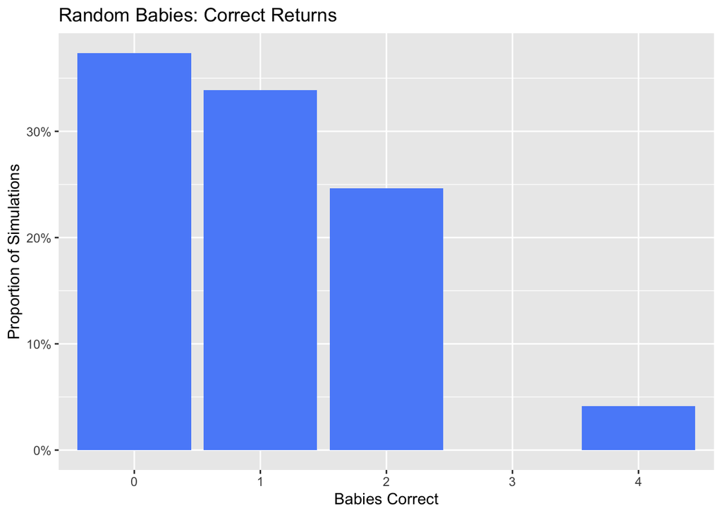

```r
baby_counts |>
  ggplot(aes(x = factor(correct), y = prop)) +
  geom_col(fill = "#5B8FF9") +
  scale_y_continuous(labels = label_percent(accuracy = 1)) +
  labs(
    x = "Babies Correct",
    y = "Proportion of Simulations",
    title = "Random Babies: Correct Returns"
  )
```

## Simulating Confidence Interval Coverage

Many students struggle with the definition of a confidence interval when first learning the concept. The interpretation that a lot of textbooks include is somthing like “if we were to repeat the study many many times, 95% of the confidence intervals would contain the true population parameter.”

We are going to implement a simulation that illustrates this statistical concept using confidence intervals for the slope parameter in a linear regression model.

Let’s break it down into a couple of steps.

As a reminder, the typical population model that we assume for a linear regression is:

$$Y = \beta_0 + \beta_1 X + \varepsilon$$

Where $\beta_0$ and $\beta_1$ are the population intercept and slope parameters and and $\varepsilon \sim N(0, \sigma^2)$ is random noise that is normally distributed with mean 0 and variance $\sigma^2$.

We will design a simulation that uses this as a “data generating model.”

**4. Fill in the code below to generate a synthetic dataset with 100 observations. We will assume that the explanatory variable $X$ is uniformly distributed from 0 to 1 and that $\sigma^2$ = 1. The synthetic data should be a data frame with 100 rows and two columns: `x` and `y`.**

```r
# define slope and intercept parameters
intercept = 2
slope = 1

# generate x vector
x <- runif(100, min = 0, max = 1)


# generate noise `ep` vector
ep <- rnorm(100, mean = 0, sd = 1)


# generate outcome from population model
y = intercept + x*slope + ep


# create an "observed data" dataframe with only the x and y vectors
sim_dat <- tibble(x = x, y = y)
```

**5. Fit a simple linear regression model of the outcome `y` on `x`.**

```r
fit_mod <- lm(y ~ x, data = sim_dat)
```

**6. Use the `tidy()` function from the `broom` package to extract a data frame from the `lm()` output that includes the slope estimate and a 95% confidence interval for the slope estimate.**

```r
tidy_fit <- tidy(fit_mod, conf.int = TRUE) |>
  filter(term == "x")
```

**7. Check whether the true population slope is inside of the estimated 95% confidence interval for that simulated dataset. Specifically, *add* a variable called `cover` to the dataframe of estimates you created in the last question (Q6) that is `1` if the population slope is in the interval and `0` if not.**

*Tip:* Remember we set `slope = 1` in the data generation (Q4) so the true population slope is $\beta_1 = 1$.

```r
tidy_fit <- tidy_fit |>
  mutate(cover = if_else(1 >= conf.low & 1 <= conf.high, 1, 0))

tidy_fit
```

```
# A tibble: 1 × 8
  term  estimate std.error statistic p.value conf.low conf.high cover
  <chr>    <dbl>     <dbl>     <dbl>   <dbl>    <dbl>     <dbl> <dbl>
1 x         1.17     0.404      2.88 0.00484    0.363      1.97     1
```

**8. Now put this all together into a function called `mycifun()`! The function should have three required arguments:**

- `beta0`,
- `beta1`, and
- `n` (the number of observations in the simulated data).**

**The function should complete the steps in Q4-7 given these arguments:**

- generate one synthetic dataset based on the data generating model specified
- fit a linear regression model to the simulated data
- check that the **population slope** is contained in the estimated 95% confidence interval for the sample slope

**The output of the function should be a data frame (or tibble) with one row and four columns:**

- the slope estimate,
- lower bound of the CI,
- upper bound of the CI, and
- whether the population slope is within the CI.

```r
mycifun <- function(beta0, beta1, n) {
  x <- runif(n, min = 0, max = 1)
  ep <- rnorm(n, mean = 0, sd = 1)
  y <- beta0 + beta1 * x + ep

  lm(y ~ x) |>
    tidy(conf.int = TRUE) |>
    filter(term == "x") |>
    mutate(cover = if_else(beta1 >= conf.low & beta1 <= conf.high, 1, 0)) |>
    select(estimate, conf.low, conf.high, cover)
}
```

**9. Run the code below to test your function.**

```r
mycifun(beta0 = 1, beta1 = 2, n = 1000)
```

```
# A tibble: 1 × 4
  estimate conf.low conf.high cover
     <dbl>    <dbl>     <dbl> <dbl>
1     1.96     1.73      2.18     1
```

**10. Now run this simulation 1,000 times using `map()` and the function you wrote (`mycifun()`). Generate data with $\beta_0 = 3$, $\beta_1 = .5$ and $n = 100$.**

*Tip:* Make sure to add a line of code to make your simulation reproducible every time you run it.

```r
set.seed(456)

ci_dat <- map(.x = 1:1000,
              .f = ~ mycifun(beta0 = 3, beta1 = 0.5, n = 100)
              )
```

**11. Use the `bind_rows()` function from the dplyr package to glue each row of your simulation together. The result of this step should be a data frame (or tibble) with 1,000 rows and 4 columns.**

```r
ci_all <- bind_rows(ci_dat)
```

**12. What is your simulated coverage rate? In otherwords, for what proportion of the iterations was the population slope within the estimated 95% confidence interval?**

```r
ci_all |>
  summarise(coverage = mean(cover))
```

```
# A tibble: 1 × 1
  coverage
     <dbl>
1    0.957
```

**13. Create a visualization to illustrate the coverage rate.**

You can create any visualization that effectively illustrates the concept. In the instructions I included a plot with my idea of an effective plot to illustrate the concept of coverage. Actually, a professor showed me a plot like this in undergrad and I have always remembered it!

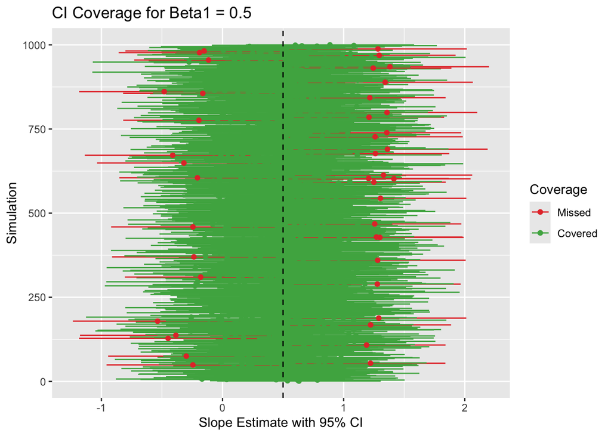

```r
ci_all |>
  mutate(iter = row_number()) |>
  ggplot(aes(y = iter, x = estimate, color = factor(cover))) +
  geom_segment(aes(x = conf.low, xend = conf.high, yend = iter)) +
  geom_point(size = 1.5) +
  geom_vline(xintercept = 0.5, linetype = "dashed") +
  scale_color_manual(
    values = c("0" = "#E53935", "1" = "#4CAF50"),
    labels = c("0" = "Missed", "1" = "Covered"),
    name = "Coverage"
  ) +
  labs(
    x = "Slope Estimate with 95% CI",
    y = "Simulation",
    title = "CI Coverage for Beta1 = 0.5"
  )
```